[figure not shown]

# ANOVA (Dataset based questions) Quiz Solutions

```python
import numpy as np
import pandas as pd
import seaborn as sns
from statsmodels.formula.api import ols      # For n-way ANOVA
from statsmodels.stats.anova import _get_covariance,anova_lm # For n-way ANOVA
%matplotlib inline
```

```python
DF = pd.read_csv('FastFood.csv')
```

```python
DF.head()
```

|  | FastFoodNames | Sales |
| --- | --- | --- |
| 0 | 1 | 2600.0 |
| 1 | 1 | 1483.8 |
| 2 | 1 | 1195.0 |
| 3 | 1 | 1470.0 |
| 4 | 1 | 903.4 |

```python
DF['FastFoodNames'].unique()
```

```
array([1, 2, 3, 4], dtype=int64)
```

```python
DF.describe()
```

|  | FastFoodNames | Sales |
| --- | --- | --- |
| count | 24.00000 | 24.000000 |
| mean | 2.50000 | 1279.108333 |
| std | 1.14208 | 737.871272 |
| min | 1.00000 | 345.000000 |
| 25% | 1.75000 | 866.350000 |
| 50% | 2.50000 | 1088.600000 |
| 75% | 3.25000 | 1477.200000 |
| max | 4.00000 | 3158.000000 |

```python
DF.info()
```

```
<class 'pandas.core.frame.DataFrame'>
RangeIndex: 24 entries, 0 to 23
Data columns (total 2 columns):
 #   Column         Non-Null Count  Dtype
---  ------         --------------  -----
 0   FastFoodNames  24 non-null     int64
 1   Sales          24 non-null     float64
dtypes: float64(1), int64(1)
memory usage: 512.0 bytes
```

```python
DF.FastFoodNames = pd.Categorical(DF.FastFoodNames)
```

## Q6 & Q7

OSR magazine reports on the largest quick-serve and fast-casual restaurants in the United States. There are various market segments (burger, chicken, sandwich, and pizza) and their corresponding sales per unit in the sample dataset FastFood.csv.

[the different fast food items are encoded as 1,2,3,4 in the dataset]

```python
formula = 'Sales ~ C(FastFoodNames)'
model = ols(formula, DF).fit()
aov_table = anova_lm(model)
print(aov_table)
```

```
                    df        sum_sq        mean_sq         F    PR(>F)
C(FastFoodNames)   3.0  2.771659e+06  923886.427222  1.894999  0.162978
Residual          20.0  9.750783e+06  487539.152833       NaN       NaN
```

## Q8

OSR magazine reports on the largest quick-serve and fast-casual restaurants in the United States. There are various market segments (burger, chicken, sandwich, and pizza) and their corresponding sales per unit in the sample dataset FastFood.csv.

At the 0.05 level of significance, after performing ANOVA to find the evidence of a difference in the mean sales per unit among the food segments, what is the difference between the following two plots? (Please do not consider the difference in scale of these plots.)

[the different fast food items are encoded as 1,2,3,4]

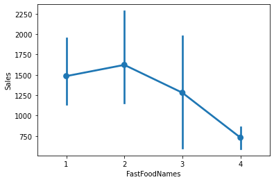

```python
sns.pointplot(x='FastFoodNames', y='Sales', data=DF)
```

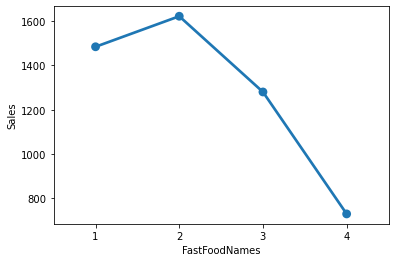

```python
sns.pointplot(x='FastFoodNames', y='Sales', data=DF,ci=None)
```